# Practical Machine Learning Course Project

## Executive Summary

Using devices such as Jawbone Up, Nike FuelBand, and Fitbit it is now possible to collect a large amount of data about personal activity relatively inexpensively. The goal of this project is to use data from accelerometers on the belt, forearm, arm, and dumbell of 6 participants. They were asked to perform barbell lifts correctly and incorrectly in 5 different ways. The idea is to generate a machine learning model to predict the manner in which exercises for the provided dataset.

## Data Preparation

First thing we need to do is to download data to a local folder. Then read the data into corresponding dataframes. Basic data cleaning is performed by setting NAs correctly to account for string values of NA and #DIV/0! which is one of the errors for numeric data.

```r
library(randomForest)
library(caret)
```

```r
url_train <- 'https://d396qusza40orc.cloudfront.net/predmachlearn/pml-training.csv'
url_test <- 'https://d396qusza40orc.cloudfront.net/predmachlearn/pml-testing.csv'
#download.file(url = url_train, destfile = 'data_train.csv')
#download.file(url = url_test, destfile = 'data_test.csv')

pml_train_data <- read.csv(file = 'data_train.csv',
                      na.strings = c('NA','#DIV/0!',''))
pml_eval_data <- read.csv(file = 'data_test.csv',
                     na.strings = c('NA','#DIV/0!',''))
```

Going through the summary of the data and peforming basic exploratory analysis, we see that the first seven columns are independent and do not affect our analysis. So these need not be considered. The remaining columns are all numeric and are hence converted into numeric type using the following steps:

```r
for(i in c(8:ncol(pml_train_data)-1)) {
  pml_train_data[,i] = as.numeric(as.character(pml_train_data[,i]))
  pml_eval_data[,i] = as.numeric(as.character(pml_eval_data[,i]))
}
```

As mentioned earlier, the first seven columns are not required. The list of required columns can be constructed through the following steps:

```r
required_columns <- colnames(pml_train_data)
required_columns <- colnames(pml_train_data[colSums(is.na(pml_train_data)) == 0])
required_columns <- required_columns[-c(1:7)]
```

## Data Analysis

We then partition the data into training and cross validation set. In my case, I have partitioned the data such that 80% of the data is used for building the model. The remaining test data is used for cross validation.

```r
set.seed(1300)
index_train <- createDataPartition(y=pml_train_data$classe, p=0.80, list=FALSE)
data_train <- pml_train_data[index_train,required_columns]
data_xval <- pml_train_data[-index_train,required_columns]
dim(data_train); dim(data_xval)
```

```
## [1] 15699    53
```

```
## [1] 3923   53
```

In my case, I have chosen a random forest method for building a prediction model. This decision was taken after a preliminary analysis of the training data which revealed that all 5 types of results are likely. This means that accuracy is very important. Using functions in the caret package, a confusion matrix for the model and the expected values is generated through the following steps.

```r
controlFunc<-trainControl(method = "cv", number = 4,allowParallel = TRUE, verboseIter = TRUE)
model<-train(classe ~ .,data = data_train, method = 'rf', trControl = controlFunc)
prediction_model<-predict(model,data_xval)
confMatrix <- confusionMatrix(prediction_model,data_xval$classe)
```

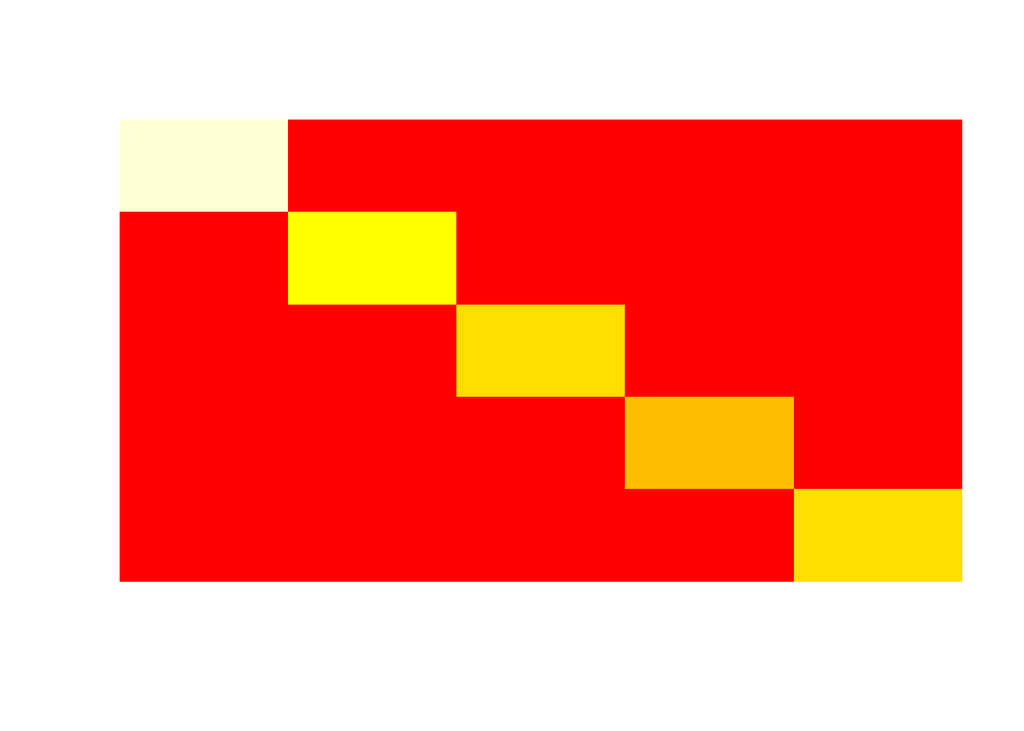

```r
cMatrix<-as.matrix(confMatrix)
image(cMatrix[,ncol(cMatrix):1], axes=FALSE)
```

We can check the summary of the confusion matrix to see how well the model has performed:

```r
confMatrix
```

```
## Confusion Matrix and Statistics
##
##           Reference
## Prediction    A    B    C    D    E
##          A 1116    8    0    0    0
##          B    0  751    3    0    0
##          C    0    0  677    5    0
##          D    0    0    4  637    1
##          E    0    0    0    1  720
##
## Overall Statistics
##
##                Accuracy : 0.9944
##                  95% CI : (0.9915, 0.9965)
##     No Information Rate : 0.2845
##     P-Value [Acc > NIR] : < 2.2e-16
##
##                   Kappa : 0.9929
##  Mcnemar's Test P-Value : NA
##
## Statistics by Class:
##
##                      Class: A Class: B Class: C Class: D Class: E
## Sensitivity            1.0000   0.9895   0.9898   0.9907   0.9986
## Specificity            0.9971   0.9991   0.9985   0.9985   0.9997
## Pos Pred Value         0.9929   0.9960   0.9927   0.9922   0.9986
## Neg Pred Value         1.0000   0.9975   0.9978   0.9982   0.9997
## Prevalence             0.2845   0.1935   0.1744   0.1639   0.1838
## Detection Rate         0.2845   0.1914   0.1726   0.1624   0.1835
## Detection Prevalence   0.2865   0.1922   0.1738   0.1637   0.1838
## Balanced Accuracy      0.9986   0.9943   0.9941   0.9946   0.9992
```

## Results

```r
final_col <- length(colnames(pml_eval_data[]))
colnames(pml_eval_data)[final_col] <- 'classe'
result <- predict(model,pml_eval_data[,required_columns])
result
```

```
##  [1] B A B A A E D B A A B C B A E E A B B B
## Levels: A B C D E
```

The results are then prepared for the assignment submission part.

```r
result<-as.character(result)
# create function to write predictions to files
pml_write_files <- function(x) {
    n <- length(x)
    for(i in 1:n) {
        filename <- paste0("problem_id_", i, ".txt")
        write.table(x[i], file=filename, quote=F, row.names=F, col.names=F)
    }
}

# create prediction files to submit
pml_write_files(result)
```